# R Notebook

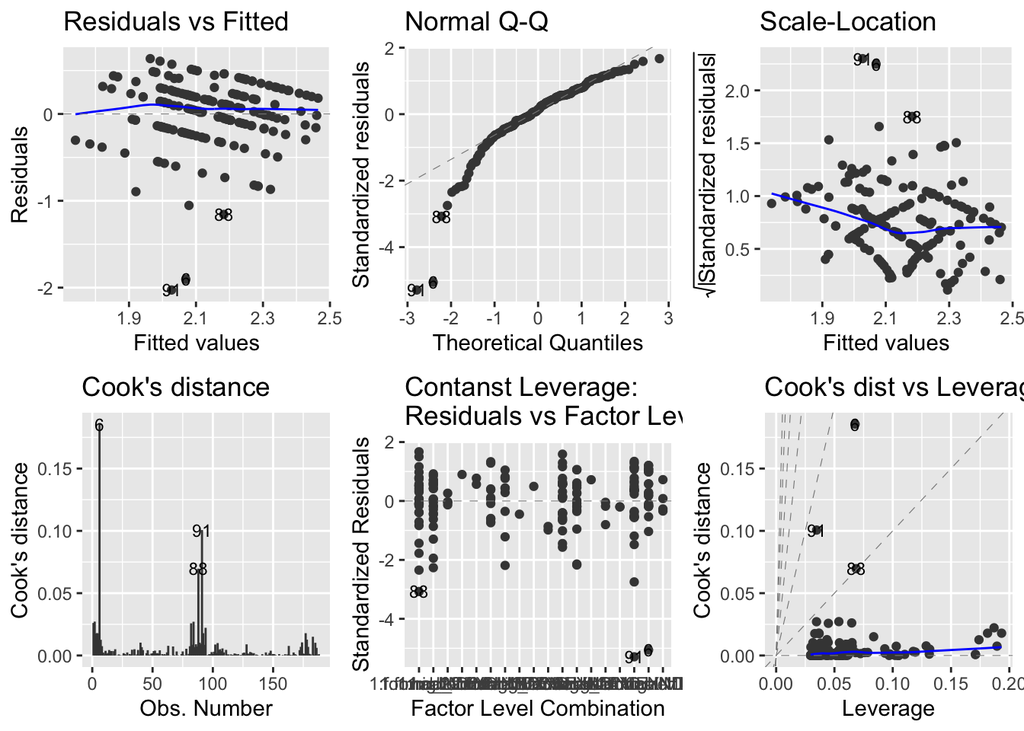

```r
autoplot(wtp_lm, which = 1:6, ncol = 3, label.size = 3)
```

```r
wtp_lm_1 <- lm(log(wtp + 1 - min(wtp)) ~ sos + info + own  + log(years_fishing) + education + factor(country), data = bind_log_final)

wtp_lm_2 <- lm(log(wtp + 1 - min(wtp)) ~ sos + info + own  + log(boat_length_m) + education + factor(country), data = bind_log_final)

wtp_lm_3 <- lm(log(wtp + 1 - min(wtp)) ~ sos + info + own  + log(boat_length_m) + education + fishtech + factor(country), data = bind_log_final)

wtp_lm_4 <- lm(log(wtp + 1 - min(wtp)) ~ sos + info + own  + log(gdp_prop) + education + fishtech + factor(country), data = bind_log_final)
summary(wtp_lm_4)
```

```
##
## Call:
## lm(formula = log(wtp + 1 - min(wtp)) ~ sos + info + own + log(gdp_prop) +
##     education + fishtech + factor(country), data = bind_log_final)
##
## Residuals:
##     Min      1Q  Median      3Q     Max
## -1.9485 -0.1379  0.0475  0.2287  0.6708
##
## Coefficients:
##                     Estimate Std. Error t value Pr(>|t|)
## (Intercept)         1.652918   0.172574   9.578   <2e-16 ***
## sos                 0.168720   0.075416   2.237   0.0265 *
## info               -0.048976   0.057060  -0.858   0.3919
## own1                0.124607   0.075519   1.650   0.1007
## own2                0.107238   0.095620   1.122   0.2636
## own3                0.007881   0.077611   0.102   0.9192
## log(gdp_prop)       0.015735   0.038133   0.413   0.6804
## educationformal     0.173059   0.152847   1.132   0.2591
## educationhigher     0.312614   0.181587   1.722   0.0869 .
## fishtech            0.202702   0.080528   2.517   0.0127 *
## factor(country)MEX  0.061143   0.077239   0.792   0.4297
## ---
## Signif. codes:  0 '***' 0.001 '**' 0.01 '*' 0.05 '.' 0.1 ' ' 1
##
## Residual standard error: 0.3843 on 177 degrees of freedom
## Multiple R-squared:  0.1602, Adjusted R-squared:  0.1127
## F-statistic: 3.376 on 10 and 177 DF,  p-value: 0.0004702
```

```r
wtp_lm_5 <- lm(log(wtp + 1 - min(wtp)) ~ sos + info + own  + log(years_fishing) + education + fishtech + factor(country), data = bind_log_final)

wtp_lm_6 <- lm(log(wtp + 1 - min(wtp)) ~ sos + info + own  + log(gdp_prop) + log(years_fishing) + education + fishtech + factor(country), data = bind_log_final)

wtp_lm_7 <- lm(log(wtp + 1 - min(wtp)) ~ sos + info + own  + education + fishtech + factor(country), data = bind_log_final)

wtp_lm_8 <- lm(log(wtp + 1 - min(wtp)) ~ sos + info + own  + log(gdp_prop) + fishtech + factor(country), data = bind_log_final)

wtp_lm_9 <- lm(log(wtp + 1 - min(wtp)) ~ sos + info + own  + log(gdp_prop) + fishtech + factor(country) + boat_own, data = bind_log_final)

wtp_lm_10 <- lm(log(wtp + 1 - min(wtp)) ~ sos + info + own  + log(gdp_prop) + fishtech + factor(country) + fishing_organization, data = bind_log_final)

wtp_lm_11 <- lm(log(wtp + 1 - min(wtp)) ~ sos + info + own  + fishtech + factor(country) + log(gdp_prop) + log(income_fishing), data = bind_log_final)

wtp_lm_12 <- lm(log(wtp + 1 - min(wtp)) ~ sos + info + own  + fishtech + factor(country) + rank_one + log(gdp_prop), data = bind_log_final)

wtp_lm_13 <- lm(log(wtp + 1 - min(wtp)) ~ sos + info + own  + fishtech + factor(country) + rank_one + log(gdp_prop) + education, data = bind_log_final)

wtp_lm_14 <- lm(log(wtp + 1 - min(wtp)) ~ sos + info + own  + fishtech + factor(country) + rank_one + education, data = bind_log_final)

summary(wtp_lm_12)
```

```
##
## Call:
## lm(formula = log(wtp + 1 - min(wtp)) ~ sos + info + own + fishtech +
##     factor(country) + rank_one + log(gdp_prop), data = bind_log_final)
##
## Residuals:
##      Min       1Q   Median       3Q      Max
## -1.89894 -0.13194  0.04102  0.20481  0.68321
##
## Coefficients:
##                      Estimate Std. Error t value Pr(>|t|)
## (Intercept)         1.9912864  0.1308438  15.219  < 2e-16 ***
## sos                 0.1889834  0.0737531   2.562  0.01123 *
## info               -0.0334712  0.0566034  -0.591  0.55506
## own1                0.1381710  0.0755981   1.828  0.06929 .
## own2                0.1193567  0.0948315   1.259  0.20983
## own3                0.0005187  0.0769336   0.007  0.99463
## fishtech            0.2299057  0.0808956   2.842  0.00501 **
## factor(country)MEX -0.0518276  0.0981728  -0.528  0.59822
## rank_oneiuu        -0.1060452  0.0951532  -1.114  0.26660
## rank_onepollution  -0.1726280  0.0924085  -1.868  0.06341 .
## rank_oneweather    -0.2635427  0.1052307  -2.504  0.01317 *
## log(gdp_prop)      -0.0011170  0.0386213  -0.029  0.97696
## ---
## Signif. codes:  0 '***' 0.001 '**' 0.01 '*' 0.05 '.' 0.1 ' ' 1
##
## Residual standard error: 0.3811 on 176 degrees of freedom
## Multiple R-squared:  0.1789, Adjusted R-squared:  0.1276
## F-statistic: 3.487 on 11 and 176 DF,  p-value: 0.0001999
```

```r
summary(wtp_lm_13)
```

```
##
## Call:
## lm(formula = log(wtp + 1 - min(wtp)) ~ sos + info + own + fishtech +
##     factor(country) + rank_one + log(gdp_prop) + education, data = bind_log_final)
##
## Residuals:
##      Min       1Q   Median       3Q      Max
## -1.88774 -0.13931  0.01846  0.20286  0.69134
##
## Coefficients:
##                     Estimate Std. Error t value Pr(>|t|)
## (Intercept)         1.764287   0.176983   9.969  < 2e-16 ***
## sos                 0.169790   0.074187   2.289  0.02330 *
## info               -0.038318   0.056196  -0.682  0.49623
## own1                0.147069   0.075025   1.960  0.05156 .
## own2                0.145134   0.095165   1.525  0.12906
## own3                0.008857   0.076415   0.116  0.90786
## fishtech            0.228714   0.080548   2.839  0.00506 **
## factor(country)MEX -0.087405   0.098941  -0.883  0.37824
## rank_oneiuu        -0.137961   0.095601  -1.443  0.15079
## rank_onepollution  -0.187144   0.092235  -2.029  0.04398 *
## rank_oneweather    -0.316526   0.107725  -2.938  0.00375 **
## log(gdp_prop)      -0.002866   0.038332  -0.075  0.94048
## educationformal     0.282697   0.155222   1.821  0.07029 .
## educationhigher     0.420611   0.183362   2.294  0.02299 *
## ---
## Signif. codes:  0 '***' 0.001 '**' 0.01 '*' 0.05 '.' 0.1 ' ' 1
##
## Residual standard error: 0.3776 on 174 degrees of freedom
## Multiple R-squared:  0.2031, Adjusted R-squared:  0.1435
## F-statistic:  3.41 on 13 and 174 DF,  p-value: 0.0001062
```

```r
summary(wtp_lm_14)
```

```
##
## Call:
## lm(formula = log(wtp + 1 - min(wtp)) ~ sos + info + own + fishtech +
##     factor(country) + rank_one + education, data = bind_log_final)
##
## Residuals:
##      Min       1Q   Median       3Q      Max
## -1.88583 -0.13863  0.01898  0.20234  0.68867
##
## Coefficients:
##                     Estimate Std. Error t value Pr(>|t|)
## (Intercept)         1.766429   0.174152  10.143  < 2e-16 ***
## sos                 0.169029   0.073275   2.307  0.02224 *
## info               -0.038691   0.055815  -0.693  0.48910
## own1                0.147022   0.074808   1.965  0.05096 .
## own2                0.145398   0.094829   1.533  0.12702
## own3                0.009046   0.076156   0.119  0.90558
## fishtech            0.227746   0.079274   2.873  0.00457 **
## factor(country)MEX -0.087742   0.098557  -0.890  0.37454
## rank_oneiuu        -0.137984   0.095328  -1.447  0.14956
## rank_onepollution  -0.186090   0.090892  -2.047  0.04212 *
## rank_oneweather    -0.315610   0.106722  -2.957  0.00353 **
## educationformal     0.282900   0.154756   1.828  0.06925 .
## educationhigher     0.420365   0.182811   2.299  0.02266 *
## ---
## Signif. codes:  0 '***' 0.001 '**' 0.01 '*' 0.05 '.' 0.1 ' ' 1
##
## Residual standard error: 0.3765 on 175 degrees of freedom
## Multiple R-squared:  0.203,  Adjusted R-squared:  0.1484
## F-statistic: 3.715 on 12 and 175 DF,  p-value: 5.251e-05
```

```r
AIC(wtp_lm, wtp_lm_1, wtp_lm_2, wtp_lm_3, wtp_lm_4, wtp_lm_5, wtp_lm_6, wtp_lm_7, wtp_lm_8, wtp_lm_9, wtp_lm_10, wtp_lm_11, wtp_lm_12, basic_wtp_lm, wtp_lm_13, wtp_lm_14) ## take the lowest one... which is wtp_lm_7... still feel like we should include a continuous variable... gdp_prop? then we would take wtp_lm_4
```

|  | df | AIC |
| --- | --- | --- |
| wtp_lm | 11 | 191.2424 |
| wtp_lm_1 | 11 | 191.6433 |
| wtp_lm_2 | 11 | 191.8891 |
| wtp_lm_3 | 12 | 186.5184 |
| wtp_lm_4 | 12 | 186.6301 |
| wtp_lm_5 | 12 | 186.2744 |
| wtp_lm_6 | 13 | 188.1469 |
| wtp_lm_7 | 11 | 184.8108 |
| wtp_lm_8 | 10 | 185.9387 |
| wtp_lm_9 | 11 | 187.6519 |

[output cut: 6 more lines]

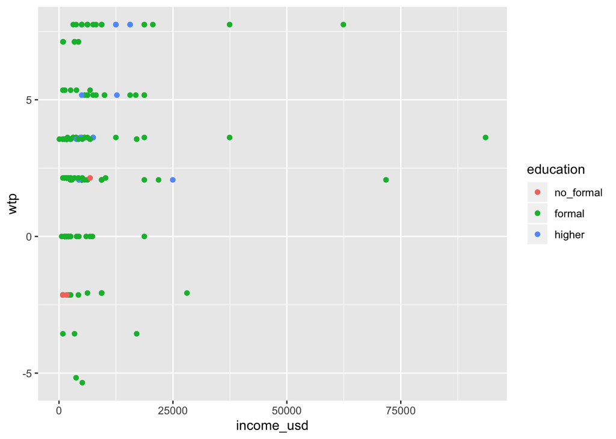

```r
## BR: New winner is wtp_lm_12. Boom.

## years_fishing adds more predictive power and has a lower p value than age -- use years_fishing
## hypothesis: the longer someone has been fishing the more value they put into having this technology.

## income/gdp_prop: hypothesis: a higher income will place a higher value on the technology... model disagrees.. could have an interesting dialogue

## education: a more educated person will likely want to pay more for this technology.. they will see more benefit in it. However, possible that we have some collinearity with education and income... should we debunk this?

ggplot(bind_log_final, aes(x = income_usd, y = wtp, color = education)) + geom_point() ## it seems that education vs income are pretty random... ok to both use in the model.
```

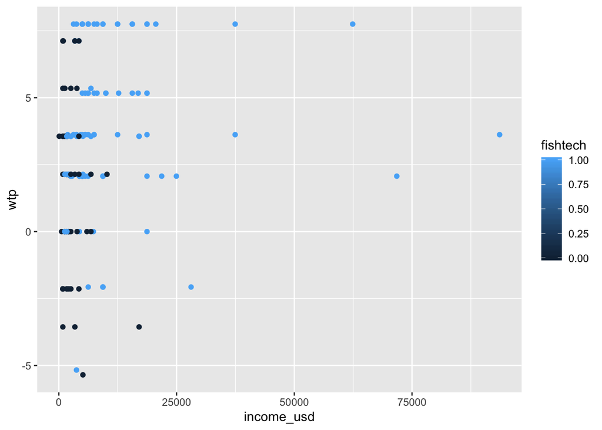

```r
## fishing_org_members: hypothesis: a larger fishing organization size will place less value on tracking tech because they feel safer while fishing... more people around to help if something goes wrong. They also probably share more information with eachother anyways?

## log(wtp) = B0 + B1*sos + B2*info + B3*own1 + B4*own2 + B5*own3 + B6*log(gdp_prop) + B7*log(years_fishing) + B8*log(fishing_org_members) + B9*educationprimary + B10*educationsecondary + B11*educationuniversity + B11*educationvocational
## note that we do not report the fixed effects in our results. "Fixed effects on the country (Mexico and Indonesia) were included"

ggplot(bind_log_final, aes(x = income_usd, y = wtp, color = fishtech)) + geom_point()
```

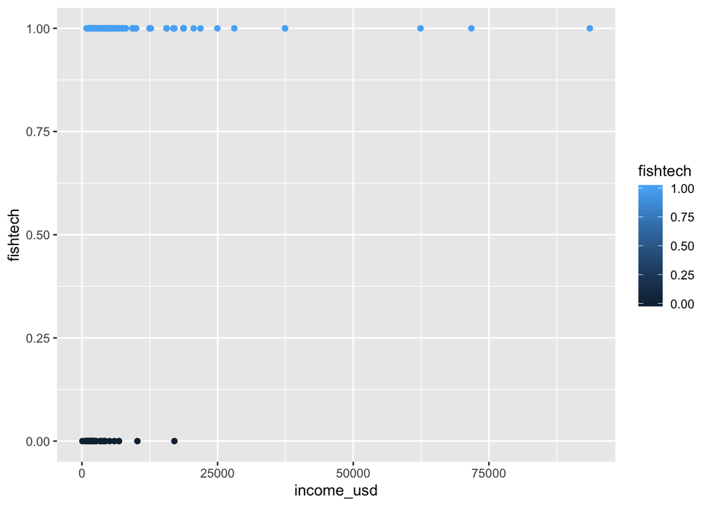

```r
ggplot(bind_log_final, aes(x = income_usd, y = fishtech, color = fishtech)) + geom_point()
```

```r
predict_lm12<-cbind(bind_log_final, fitted = fitted(wtp_lm_12)) %>%
  mutate(wtp_predict = (exp(fitted) - 1 + min(wtp)))

library(stargazer)
lm_12_lmtbl <- stargazer(wtp_lm_12, type = "html", out = "AIC.htm")
```

|  | *Dependent variable:* |
| --- | --- |
|  | log(wtp + 1 - min(wtp)) |
| sos | 0.189** |
|  | (0.074) |
| info | -0.033 |
|  | (0.057) |
| own1 | 0.138* |
|  | (0.076) |
| own2 | 0.119 |
|  | (0.095) |
| own3 | 0.001 |
|  | (0.077) |
| fishtech | 0.230*** |
|  | (0.081) |
| factor(country)MEX | -0.052 |
|  | (0.098) |
| rank_oneiuu | -0.106 |
|  | (0.095) |
| rank_onepollution | -0.173* |
|  | (0.092) |
| rank_oneweather | -0.264** |
|  | (0.105) |
| log(gdp_prop) | -0.001 |
|  | (0.039) |
| Constant | 1.991*** |
|  | (0.131) |
| Observations | 188 |
| R<sup>2</sup> | 0.179 |
| Adjusted R<sup>2</sup> | 0.128 |
| Residual Std. Error | 0.381 (df = 176) |
| F Statistic | 3.487*** (df = 11; 176) |
| *Note:* | p<0.1; p<0.05; p<0.01 |

```r
# calculate exact percent change in WTP for our categorical variables
coef_lm <- as.data.frame(wtp_lm$coefficients) %>%
  tibble::rownames_to_column("Beta") %>%
  mutate(on = exp(wtp_lm$coefficients) - 1 , off = exp(-wtp_lm$coefficients) - 1)
```

How to interpret our coefficients: The coefficient on a dummy variable with a log-transformed Y variable is interpreted as the percentage change in Y associated with having the dummy variable characteristic relative to the omitted category, with all other included X variables held fixed.

Justification for using a log-log model: For interpretation. In economics, we are sometimes interested how a percentage change in x affects the percentage change in y. This called elasticity. We can estimate elasticity (f) by using a log-log model